# Guia de Arquitetura e Organização de Computadores

Feito por: Sara Dutra

Últilma atualização: 06/09/2024

Este site foi criado por uma estudante de Ciência da Computação e oferece um recurso adicional dos principais tópicos da disciplina. :D

[GitHub](https://github.com/Sarinha09/AOC1) [IAS Machine](https://www.ic.unicamp.br/~edson/disciplinas/mc404/2017-2s/abef/IAS-sim/) Resposta lista

## Introdução

#### Organização x Arquitetura

A **arquitetura** de computador é como se fosse o “design” e a estrutura lógica do sistema, e de como um computador deve funcionar do ponto de vista do programador, que afeta diretamente a execução de programas. Isso inclui: Conjuntos de instruções, registradores e memória.  
Já a **organização** de computador é mais sobre como o computador é construído internamente para seguir o “design” que a arquitetura define. É como os detalhes de como as peças do computador estão conectadas e funcionam juntas. Inclui: Unidades operacionais, sinais de controle e interfaces de hardware.

Aqui uma tabela de Características e Aspectos de Arquitetura e Organização de Computadores

| Característica | Arquitetura | Organização |
| --- | --- | --- |
| Define o que o processador pode fazer | A | - |
| Formato das instruções | A | - |
| Número de registradores disponíveis | A | - |
| Detalhes da implementação do hardware | - | O |
| Tamanho dos operandos (número de bits) | A | - |
| Conexões entre a CPU e dispositivos de E/S | - | O |
| Facilita a compreensão das funções do sistema | A | - |
| Envolve lógica | A | - |
| Mecanismos de endereçamento de memória | A | - |
| Interface entre o computador e periféricos | - | O |
| Mapeia todas as unidades de um sistema, sua interconexão e disposição | - | O |
| Desempenho do barramento de dados | - | O |

#### Função x Estrutura

A **função** refere-se ao propósito ou papel que cada componente individual desempenha dentro do sistema. É o que cada parte faz e como contribui para o funcionamento geral. Há somente quatro funções básicas que podem ser apresentadas pelo computador:

Processamento de Dados: Os dados podem assumir várias formas e exigir diferentes tipos de processamento, mas existem poucos métodos fundamentais de processamento.

Armazenamento de Dados:  
- Curto Prazo: Dados temporários são armazenados enquanto estão sendo processados.  
- Longo Prazo: Dados são armazenados em arquivos para recuperação e atualização futura.

Movimentação de Dados:  
- Entrada-Saída (E/S): Dados são recebidos ou enviados para dispositivos periféricos diretamente conectados ao computador.  
- Comunicações de Dados: Dados são transferidos entre o computador e dispositivos remotos.

Controle: A unidade de controle gerencia e coordena o uso dos recursos do computador e o desempenho das suas partes funcionais conforme as instruções recebidas.

**Estrutura** inclui a disposição física de todos os componentes do computador: CPU, memória, placas de expansão, e como tudo está conectado fisicamente (placa-mãe, cabos, etc.). Por exemplo, onde a RAM é instalada na placa-mãe e como a CPU é montada sobre a placa-mãe.

A estrutura interna de um computador de processador único tradicional, há quatro componentes estruturais principais:

Unidade central de processamento: controla a operação de um computador e realiza suas funções e processamento de dados; costuma ser referida simplesmente como processador.  
Memória principal: armazena dados.  
E/S: move dados entre o computador e seu ambiente externo.  
Sistema de interconexão: algum mecanismo que proporciona comunicação entre CPU, memória principal e E/S. Um exemplo comum de um sistema de interconexão é o barramento do sistema, que consiste em um número de fios condutores aos quais todos os outros componentes se conectam.

#### Abordagem de Projeto de um Sistema Computador

Computadores contemporâneos contêm milhões de componentes eletrônicos elementares. Como, então, alguém poderia descrevê-los com clareza? Para descrever e projetar esses sistemas complexos de maneira clara e organizada, utiliza-se uma **abordagem hierárquica**.  
**Hierarquia:** Em um sistema hierárquico, cada nível do sistema é composto por subsistemas que, por sua vez, podem ser divididos em outros subsistemas menores, até chegar ao nível mais básico dos componentes elementares. Essa organização facilita o entendimento e o projeto de sistemas complexos.

A abordagem top-down (de cima para baixo) sugere começar com uma visão geral do sistema completo e, em seguida, decompor esse sistema em suas partes menores, descendo pelos níveis da hierarquia. Essa abordagem é considerada mais clara e eficaz para descrever sistemas complexos.

- Aplicação no Projeto de Computadores: Quando projetamos um computador, começamos identificando os principais componentes, como a CPU, memória e dispositivos de entrada/saída. Depois, detalhamos cada componente, como a estrutura interna da CPU ou como a memória está organizada. Esse processo continua até chegarmos ao nível mais básico dos componentes eletrônicos.

Ao lidar com sistemas complexos, a hierarquia é essencial para gerenciar a complexidade. A estrutura define como os componentes são organizados, enquanto a função descreve o que cada componente faz. A abordagem top-down facilita o entendimento, permitindo que os projetistas ou engenheiros se concentrem em um nível de abstração de cada vez, antes de descer para detalhes mais específicos. Isso permite um projeto mais organizado e compreensível de sistemas complexos como os computadores.

## Estrutura da Máquina IAS

A Máquina IAS (International Algebraic Language System) é um modelo teórico de computador desenvolvido na década de 1950 por John von Neumann e sua equipe no Instituto para Estudos Avançados (IAS). Este modelo foi fundamental no desenvolvimento das primeiras arquiteturas de computadores modernos e é um exemplo clássico de uma máquina com arquitetura de **von Neumann**.

#### Estrutura

A estrutura do computador IAS consiste em:

- Uma **memória principal**, que armazena tanto dados como instruções.
- Uma **unidade lógica e aritmética (ALU)** capaz de operar os dados binários.
- Uma **unidade de controle**, que interpreta instruções que estão na memória e faz que sejam executadas.
- **Equipamento de entrada/saída (E/S)** controlado pela unidade de controle.

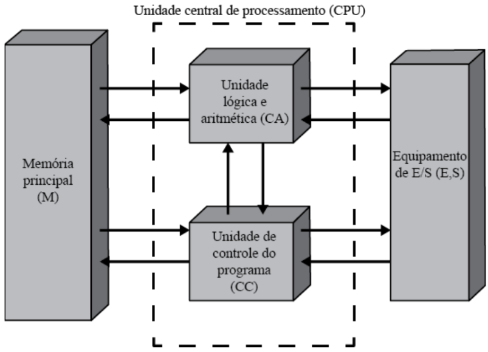

(1) Estrutura da máquina IAS

#### Registradores

A unidade de controle comanda o IAS buscando instruções a partir da memória e executando-as uma por vez. Tanto a unidade de controle como a ALU contêm locais de armazenamento, chamados de registradores, definidos desta maneira:

- **Registrador de buffer de memória (MBR):** contém uma palavra a ser armazenada na memória ou enviada à unidade E/S ou é usado para receber uma palavra a partir da memória ou a partir da unidade E/S.
- **Registrador de endereço de memória (MAR):** especifica o endereço na memória da palavra a ser escrito a partir ou lido na MBR.
- **Registrador de instruções (IR):** contém o opcode de 8 bits, da instrução opcode que está sendo executada.
- **Registrador de buffer de instrução (IBR):** empregado para manter temporariamente a instrução da direita, da palavra da memória.
- **Contador do programa (PC):** contém o endereço do próximo par de instruções a ser buscado na memória.
- **Acumulador (AC) e quociente-multiplicador (MQ):** empregado para manter temporariamente os operandos e os resultados das operações da ALU. Por exemplo, o resultado da multiplicação de dois números de 40 bits é um número de 80 bits; os 40 bits mais significativos são armazenados no AC, e os menos significativos no MQ.

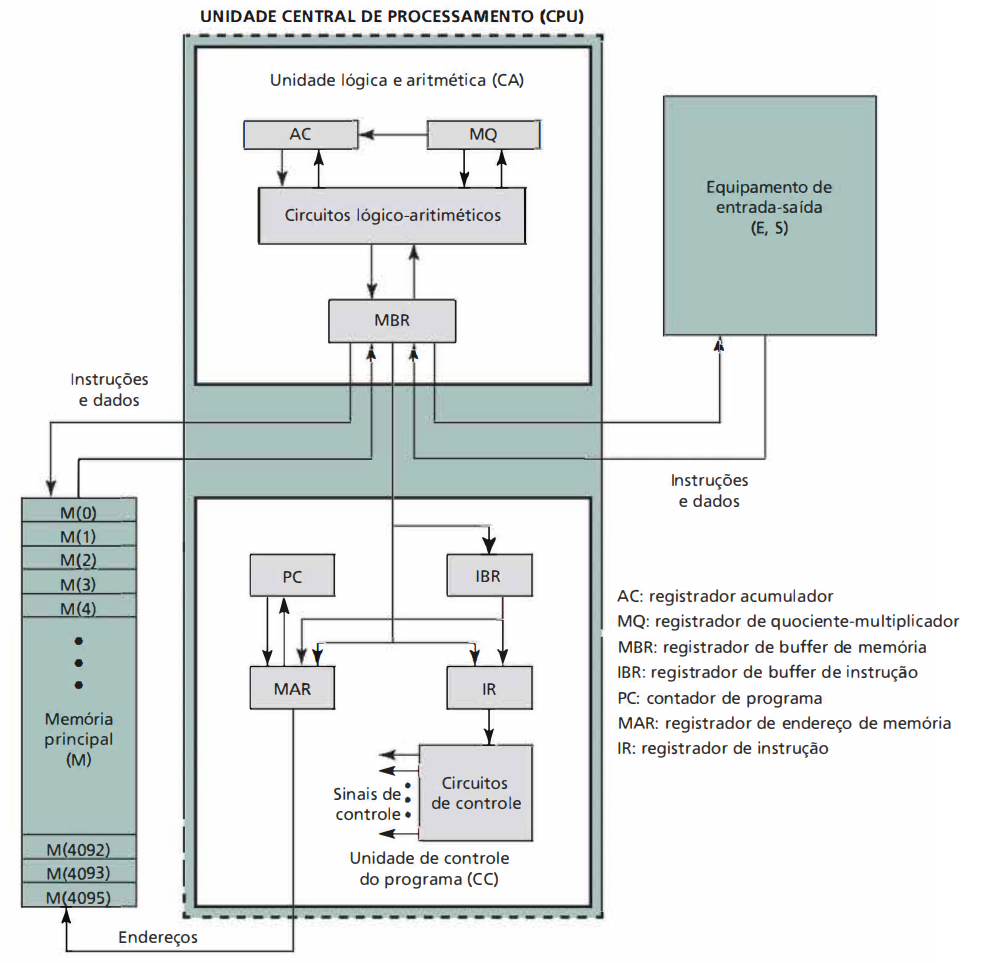

(2) Estrutura dos registradores

#### Instruções

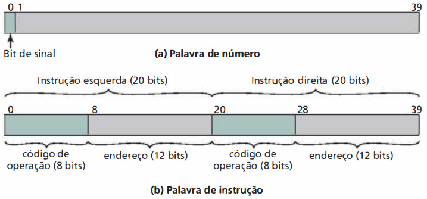

(3) Mémoria da instrução

O computador IAS tem um total de 21 instruções, que são listadas na Tabela 1.1. Elas podem ser agrupadas da seguinte maneira:

- **Transferência de dados:** move os dados entre a memória e os registradores da ALU ou entre dois registradores da ALU.
- **Saltos incondicionais:** em geral, a unidade de controle executa as instruções em sequência a partir da memória. Essa sequência pode ser mudada por uma instrução de salto, o que facilita as operações repetitivas.
- **Saltos condicionais:** a execução de um salto pode ser dependente de uma condição, permitindo assim pontos de decisão.
- **Aritmética:** operações desempenhadas pela ALU.
- **Modificação do endereço:** permite que os endereços sejam calculados na ALU e então inseridos nas instruções armazenadas na memória. Isso possibilita a um programa uma flexibilidade de endereçamento considerável.

[output not shown]

Na Tabela acima apresenta as instruções (excluindo instruções de E/S) em uma forma simbólica fácil de ler.

## Questões de desempenho

A Lei de Moore, proposta por Gordon Moore, cofundador da Intel, prevê que o número de transistores em um chip dobraria a cada 18 meses, mantendo o custo do chip constante. Isso resultaria em chips mais poderosos e acessíveis ao longo do tempo. A maior densidade de transistores leva a caminhos elétricos menores, aumentando o desempenho do chip. Chips menores também consomem menos energia, exigem menos refrigeração e são mais confiáveis devido a menos interconexões. A Lei de Moore tem sido fundamental no avanço da tecnologia, embora a taxa de progresso tenha desacelerado recentemente.

#### Gargalo da Arquitetura Von Neumann

Embora a velocidade do processador tenha aumentado rapidamente, a velocidade com que os dados podem ser transferidos entre a memória principal e o processador ficou para trás, a velocidade da memória não acompanha a do processador, criando um gargalo onde o processador fica esperando pela memória, o que limita o desempenho geral do sistema.

Existem várias maneiras de um arquiteto de sistemas atacar esse problema, todas refletidas nos projetos atuais de computador. Considere os seguintes exemplos:

- **Aumentar o número de bits** que são recuperados ao mesmo tempo, tornando a DRAM “mais larga” em vez de “mais profunda” e usando caminhos de dados largos no barramento.
- **Alterar a interface da DRAM** para torná-la mais eficiente, incluindo uma cache ou outro esquema de buffering no chip de DRAM.
- **Reduzir a frequência de acesso à memória** incorporando estruturas de cache cada vez mais complexas e eficientes entre o processador e a memória principal. Isso inclui a incorporação de uma ou mais caches no chip do processador, bem como uma cache fora do chip, próxima ao chip do processador.
- **Aumentar a largura de banda de interconexão** entre os processadores e a memória usando barramentos de velocidade mais alta e usando uma hierarquia de barramentos para armazenar e estruturar o fluxo de dados.

#### Melhorias na organização e na arquitetura do chip

À medida que os projetistas lutam com o desafio de balancear o desempenho do processador com o da memória principal e de outros componentes do computador, permanece a necessidade de aumentar a velocidade do processador. Para isso, existem três técnicas:

- **Aumentar a velocidade de hardware do processador**: Esse aumento deve-se fundamentalmente à diminuição do tamanho das portas lógicas no chip do processador, de modo que mais portas possam ser alocadas mais próximas uma das outras, aumentando a frequência do clock. Com portas mais próximas, o tempo de propagação para os sinais é significativamente reduzido, permitindo um aumento de velocidade do processador. Um aumento na frequência do clock significa que operações individuais são executadas mais rapidamente
- **Aumentar o tamanho e a velocidade das caches**:interpostas entre o processador e a memória principal, dedicando uma parte do próprio chip do processador à cache, os tempos de acesso à cache caem significativamente.
- **Fazer mudanças na organização e na arquitetura do processador**: que aumentam a velocidade efetiva da execução da instrução. Tipicamente, isso envolve o uso do paralelismo de uma forma ou de outra.

Tradicionalmente, o fator dominante nos ganhos de desempenho tem sido em aumentos na velocidade do clock e densidade lógica. Contudo, à medida que a velocidade do clock e a densidade lógica aumentam, diversos obstáculos tornam-se mais significativos (INTEL, 2004):

- **Potência**: à medida que a densidade da lógica e a velocidade do clock em um chip aumentam, também aumenta a densidade de potência (Watts/cm2). A dificuldade de dissipar o calor gerado em chips de alta densidade e alta velocidade está se tornando um sério problema de projeto (GIBBS, 2004, BORKAR, 2003).
- **Atraso de RC**: a velocidade com que os elétrons podem se movimentar em um chip entre os transistores é limitada pela resistência e capacitância dos fios de metal que os conectam; especificamente, o atraso aumenta à medida que o produto RC aumenta. À medida que os componentes no chip diminuem de tamanho, as interconexões de fios tornam-se mais finas, aumentando a resistência. Além disso, os fios estão mais próximos, aumentando a capacitância.
- **Latência e taxa de transferência da memória**: a velocidade de acesso à memória (latência) e a taxa de transferência limitam as velocidades do processador, conforme já foi discutido.

Assim, haverá mais ênfase nas abordagens de organização e arquitetura para melhorar o desempenho.

#### Técnicas Avançadas para Ganhos de Desempenho

A partir do final da década de 1980, e continuando por cerca de quinze anos, duas estratégias principais foram utilizadas para aumentar o desempenho além do que pode ser alcançado simplesmente aumentando a velocidade do clock.

Primeiro, houve um aumento na **capacidade da cache**. Agora, existem em geral dois ou três níveis de cache entre o processador e a memória principal. À medida que a densidade do chip tem aumentado, mais da memória cache tem sido incorporada no chip, permitindo um acesso mais rápido a ela. Por exemplo, o chip Pentium original dedicava cerca de 10% da área do chip a uma cache. Os chips atuais dedicam mais da metade de sua área a caches. E, geralmente, cerca de três quartos da outra metade são para controle e buffering relacionados ao pipeline.

Segundo, a lógica de execução de instrução dentro de um processador tornou-se cada vez mais complexa para permitir a execução paralela das instruções dentro do processador. Duas técnicas de projeto dignas de nota são: **pipeline** e **superescalar**.

- **Pipeline**: funciona como uma linha de montagem em uma fábrica, permitindo que diferentes estágios de execução de instruções distintas ocorram ao mesmo tempo pelo pipeline.
- **Superescalar**: basicamente permite múltiplos pipelines dentro de um único processador, de modo que as instruções que não dependem umas das outras possam ser executadas em paralelo.

Porém, simplesmente contar com o aumento na frequência do clock para aumentar o desempenho faz com que nos deparemos com o problema de dissipação de potência já citado. Quanto maior a frequência do clock, maior a potência a ser dissipada, sem falar que alguns limites físicos fundamentais já estão sendo atingidos.

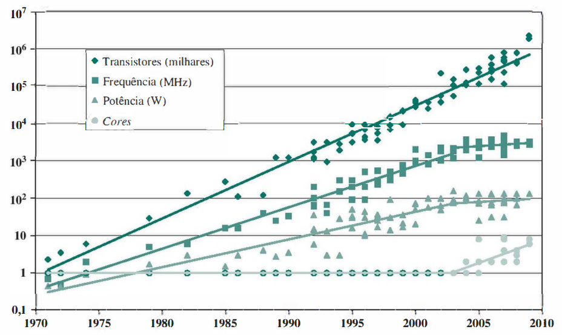

(7) Tendências dos processadores.

Para continuar aumentando o desempenho, os desenvolvedores tiveram de encontrar modos de explorar o crescente número de transistores, em vez de simplesmente elaborar um processador mais complexo. A resposta em anos recentes foi o desenvolvimento de computadores **multicore**.

#### Multicore

O uso de diversos processadores em um único chip, também chamado de múltiplos cores ou multicore, proporciona o potencial para aumentar o desempenho sem aumentar a frequência do clock.  
Os estudos indicam que, dentro de um processador, o aumento no desempenho é mais ou menos proporcional à raiz quadrada do aumento na complexidade (BORKAR, 2003). Mas, se o software pode suportar o uso efetivo de múltiplos processadores, então duplicar o número de processadores quase duplica o desempenho. Assim, a estratégia é usar dois processadores simplificados no chip em vez de um processador mais complexo.  
Além disso, com dois processadores, as caches grandes são justificadas. Isso se dá porque o consumo de energia da lógica de memória em um chip é muito menor do que da lógica de processamento.

#### Lei de Amdahl

Não adianta o número de processadores que voc~e tenha em um único computador. Todo programa tem uma fração de código serial que não pode ser paralelizada.Isso limita o Speedup (diminuição do tempo de processamento) na execução do programa.

Agora imagine que você tem um programa de computador que realiza várias tarefas. Algumas dessas tarefas podem ser aceleradas se você usar mais processadores, mas outras não podem. A Lei de Amdahl ajuda a determinar o quão mais rápido o programa inteiro pode ficar se você melhorar apenas uma parte dele.

Principais pontos:

- **Speedup**: Refere-se ao aumento de velocidade de um programa quando se utiliza múltiplos processadores.
- **Paralelização do Código**: Para alcançar um aumento significativo de desempenho, o código precisa ser altamente paralelizável, ou seja, dividido em tarefas que podem ser executadas simultaneamente.
- **Limitações e Retornos Decrescentes**: Mesmo com mais processadores, o aumento de desempenho atinge um limite, conhecido como “retornos decrescentes”. Isso significa que adicionar mais processadores não resulta em uma melhoria proporcional do desempenho.

Aplicações:

- **Servidores**: Beneficiam-se de múltiplos processadores, pois podem manter várias conexões simultaneamente.
- **Bancos de Dados**: Podem ser otimizados dividindo tarefas em processos paralelos, melhorando o desempenho em consultas e operações complexas.

A conclusão de Amdahl é que, embora a paralelização possa melhorar o desempenho, ela tem limites, e o ganho real depende da capacidade do código e das tarefas de serem executados em paralelo.

#### Dicas importantes para um bom projeto

- Projetar dando atenção a Lei de Moore
- Usar abstração para simplificar o projeto
- Tornar o caso comum mais rápido
- Melhorar o desempenho explorando o paralelismo
- Melhorar o desempenho explorando o pipelining
- Melhorar o desempenho aplicando a predição
- Empregar sistema hierárquico de memórias
- Obter estabilidade pelo emprego de redundância

## Ciclo de instrução

#### Função do Computador

A função básica realizada por um computador é a execução de um programa, que é uma sequência de **instruções**, e em cada passo, uma operação lógica ou aritmética é realizada. Para cada operação, um conjunto diferente de sinais de controle é necessário.

Em sua forma mais simples, o processamento de instrução consiste em duas etapas: o processador **busca** instruções da memória, uma de cada vez, e **executa** cada instrução. A execução do programa consiste em repetir o processo de busca e execução de instrução.

As duas etapas são conhecidas como **ciclo de busca (fetch)** e **ciclo de execução**. A execução do programa só termina se a máquina for desligada, se houver algum tipo de erro irrecuperável ou se for encontrada uma instrução do programa que interrompa o computador.

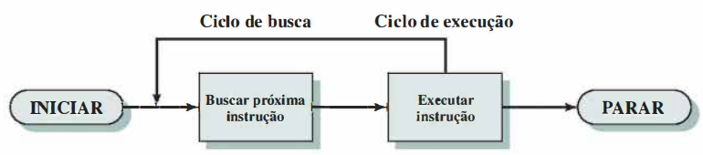

(4) Ciclo de instrução básico

#### Ciclo de Busca e execução

No início de cada ciclo de instrução, o processador busca uma instrução da memória. Em um processador típico, um registrador chamado contador de programa (PC) mantém o endereço da instrução a ser buscada em seguida. O processador sempre incrementa o PC após cada busca de instrução, de modo que buscará a próxima instrução em sequência.  
A instrução lida é carregada em um registrador no processador, conhecido como registrador de instrução (IR). A instrução contém bits que especificam a ação que o processador deve tomar. O processador interpreta a instrução e realiza a ação solicitada. Em geral, essas ações estão em uma destas quatro categorias:

- **Processador memória**: os dados podem ser transferidos do processador para a memória ou da memória para o processador.
- **Processador E/S**: os dados podem ser transferidos de ou para um dispositivo periférico, transferindo entre o processador e um módulo de EIS.
- **Processamento de dados**: o processador pode realizar alguma operação aritmética ou lógica sobre os dados.
- **Controle**: uma instrução pode especificar que a sequência de execução seja alterada. Por exemplo, o processador pode buscar uma instrução do local 149, que especifica que a próxima instrução seja do local 182. O processador se lembrará desse fato definindo o contador de programa como 182. Assim, no próximo ciclo de busca, a instrução será lida do local 182, em vez de 150.

A figura (5) mostra um diagrama de estado. Para qualquer ciclo de instrução dado, alguns estados podem ser nulos e outros podem ser visitados mais de uma vez. Os estados podem ser descritos da seguinte forma:

- **Cálculo de endereço de instrução**: determina o endereço da próxima instrução a ser executada. Normalmente, isso envolve acrescentar um número fixo ao endereço da instrução anterior. Por exemplo, se cada instrução tem 16 bits de extensão e a memória é organizada em palavras de 16 bits, então some 1 ao endereço anterior. Se, em vez disso, a memória é organizada em bytes (palavras de 8 bits) endereçáveis individualmente, então some 2 ao endereço anterior.
- **Busca da instrução**: lê a instrução de seu local da memória para o processador.
- **Decodificação da operação da instrução**: analisa a instrução para determinar o tipo de operação a ser realizado e o operando ou operandos a serem utilizados.
- **Cálculo do endereço do operando**: se a operação envolve referência a um operando na memória ou disponível via E/S, então determina o endereço do operando.
- **Busca do operando**: busca o operando da memória ou o lê da E/S.
- **Operação dos dados**: realiza a operação indicada na instrução.
- **Armazenamento do operando**: escreve o resultado na memória ou envia para a E/S.

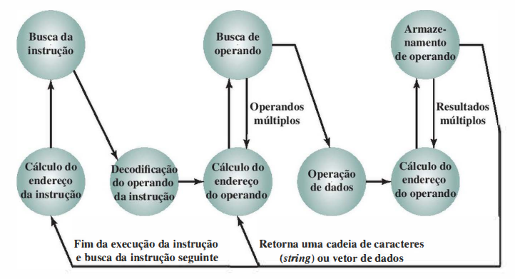

(5) Ciclo de instrução básico em diagrama

#### Interrupções

Praticamente todos os computadores oferecem um mecanismo por meio do qual outros módulos (E/S, memória) podem interromper o processamento normal do processador. A Tabela 1 lista as classes mais comuns de interrupções.

Tabela de Tipos de Interrupções (1)

[output not shown]

Do ponto de vista do programa do usuário, uma interrupção é apenas isto: uma interrupção da sequência de execução normal. Quando o processamento da interrupção termina, a execução é retomada. Assim, o programa do usuário não precisa conter qualquer código especial para acomodar as interrupções; o processador e o sistema operacional são responsáveis por suspender o programa do usuário e depois retomá-lo no mesmo ponto.

Para acomodar as interrupções, um **ciclo de interrupções** é acrescentado ao **ciclo de instrução**, como mostra a Figura 6. No ciclo de interrupção, o processador verifica se houve alguma interrupção, que é indicada pela presença de um **sinal de interrupção**. Se nenhuma interrupção estiver pendente, o processador prossegue para o ciclo de busca, lendo a próxima instrução do programa atual. Se uma interrupção estiver pendente, o processador faz o seguinte:

- **Suspende** a execução do programa que está sendo executado e **salva** seu contexto. Isso significa salvar o endereço da próxima instrução a ser executada (conteúdo atual do contador de programa) e quaisquer outros dados relevantes à atividade atual do processador.
- **Armazena** no contador do programa (PC) o endereço inicial de uma rotina de tratamento de interrupções.

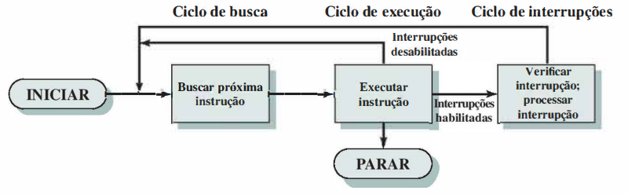

(6) Ciclo de instrução com interrupção

O processador, agora, continua com o ciclo de busca, obtendo a primeira instrução da rotina de tratamento de interrupção, que tratará a interrupção. Quando a rotina de tratamento de interrupção terminar, o processador poderá retomar a execução do programa do usuário no ponto da interrupção.

##### Múltiplas interrupções

Duas técnicas podem ser utilizadas para lidar com múltiplas interrupções. A primeira é **desativar** as interrupções enquanto uma interrupção estiver sendo processada. Uma interrupção desabilitada significa simplesmente que o processador pode ignorar e ignorará esse sinal de requisição de interrupção. Se uma interrupção ocorrer durante esse tempo, ela, de modo geral, permanecerá pendente e será verificada pelo processador depois que ele tiver habilitado as interrupções. Essa técnica é boa e simples, pois as interrupções são tratadas em ordem estritamente **sequencial**.

Uma segunda técnica é definir **prioridades** para interrupções e permitir que uma interrupção de maior prioridade faça com que um tratamento de interrupção com menor prioridade seja interrompido. Quando a interrupção de mais alta prioridade foi processada, o processador retorna a interrupção anterior.

## Aritmética computacional

## Bibliografia

STALLINGS, William. Arquitetura e Organização de Computadores.  
Download do livro: